# Interacting with spatial data from a STAC catalogue

The STAC currently contains the following collections:

```r
stac("http://io.biodiversite-quebec.ca/stac/") %>%
  collections() %>%
  get_request()
```

```
## ###STACCollectionList
## - collections (12 item(s)):
##   - chelsa-clim
##   - colombia-lc
##   - gfw-lossyear
##   - soilgrids
##   - ghmts
##   - gfw-treecover2000
##   - gfw-gain
##   - chelsa-monthly
##   - esacci-lc
##   - chelsa-clim-proj
##   - stressors_qc
##   - silvis
## - field(s): collections, links
```

### 1. Defining the study extent

Whatever the chosen method used, the study extent used to interact with the stac catalogue must be a bbox class object in a user-specified projection system. Let’s choose a projection system for Québec.

```r
srs_cube <- "EPSG:6623" #
```

We can then create a bbox from available points (for instance, based on a set of observations), from a shapefile or directly from a vector of coordinates.

#### 1.1. From points

Let’s download [Glyptemys insculpta](https://en.wikipedia.org/wiki/Wood_turtle) observations from GBIF. We apply basic tests to ensure there are no 0, non-numeric and not available coordinates using `CoordinateCleaner` package.

```r
obs <- rgbif::occ_data(scientificName = "Glyptemys insculpta", hasCoordinate = TRUE, limit = 5000)$data

obs <- CoordinateCleaner::cc_val(obs, lon = "decimalLongitude",
                                 lat = "decimalLatitude", verbose = T, value = "clean")
```

```
## Testing coordinate validity
```

```
## Removed 0 records.
```

```r
obs <- CoordinateCleaner::cc_zero(obs, lon = "decimalLongitude",
                                        lat = "decimalLatitude", buffer = 0.5,
                                        verbose = T, value = "clean")
```

```
## Testing zero coordinates
## Removed 0 records.
```

```r
obs <- dplyr::select(obs, decimalLongitude, decimalLatitude) %>%
  dplyr::rename(lon = decimalLongitude) %>%
  dplyr::rename(lat = decimalLatitude)
head(obs)
```

```
## # A tibble: 6 x 2
##     lon   lat
##   <dbl> <dbl>
## 1 -78.0  39.5
## 2 -72.3  42.3
## 3 -78.5  39.2
## 4 -72.3  42.1
## 5 -78.5  39.4
## 6 -73.0  44.2
```

We reproject the coordinates to a user-specified projection system and create the box.

```r
srs_obs <-"EPSG:4326" # initial observations projection system
buffer <- 0

# Reproject the obs to the data cube projection
obs_pts <-
          stacatalogue::project_coords(obs,
                         lon = "lon",
                         lat = "lat",
                         proj_from = srs_obs,
                         proj_to = srs_cube )

# Create the extent (data cube projection)
bbox <- stacatalogue::points_to_bbox(obs_pts, buffer = buffer)
```

#### 1.2. From a shapefile

```r
path_shp <- "your_shapefile_path"
shp <- sf::st_read(path_shp)

bbox <- stacatalogue::shp_to_bbox(shp,
        proj_to = srs_cube)
```

#### 1.3. From a vector

```r
my_vector <- c(xmin = -30, xmax = -28, ymax = 20, ymin = 21)
bbox <- my_vector %>% sf::st_bbox(crs = "EPSG:4326") %>%
        sf::st_as_sfc() %>% sf::st_transform(crs = srs_cube) %>%
        sf::st_bbox()
```

### Selecting variables or layers

Now, you have to select the variables that you are going to load from a specific collection. Each collection has two types of fields: layers and variables. To understand the difference between the two concepts, let’s take the example of the collection `chelsa_monthly`. We retrieve the list of layers and variables names using the function `get_info_collection`.

```r
info_chelsa_monthly <- get_info_collection(stac_path =
                                  "http://io.biodiversite-quebec.ca/stac/",
                                collections = c('chelsa-monthly'),
                                bbox = NULL)
```

Variables:

```r
print(info_chelsa_monthly$variables)
```

```
##  [1] "tasmax"  "tas"     "tasmin"  "pr"      "vpd"     "sfcWind" "pet"
##  [8] "hurs"    "cmi"     "clt"
```

Layers:

```r
print(head(info_chelsa_monthly$layers))
```

```
## [1] "tasmax_12_2019" "tas_12_2019"    "tasmax_11_2019" "tas_11_2019"
## [5] "tasmax_10_2019" "tas_10_2019"
```

Variables corresponds to each unique variable your collection contains. Each variable can be derived in several layers if you have a temporal series, as in `chelsa_monthly` (one layer per month, per year and per variable). If the collection does not include any dimension except the variables, the list of variables and layers will be the same:

```r
info_chelsa <- get_info_collection(stac_path =
                                  "http://io.biodiversite-quebec.ca/stac/",
                                collections = c('chelsa-clim'),
                                bbox = NULL)
print(info_chelsa$layers)
```

```
##  [1] "bio9"  "bio8"  "bio7"  "bio6"  "bio5"  "bio4"  "bio3"  "bio2"  "bio19"
## [10] "bio18" "bio17" "bio16" "bio15" "bio14" "bio13" "bio12" "bio11" "bio10"
## [19] "bio1"
```

```r
print(info_chelsa$variables)
```

```
##  [1] "bio9"  "bio8"  "bio7"  "bio6"  "bio5"  "bio4"  "bio3"  "bio2"  "bio19"
## [10] "bio18" "bio17" "bio16" "bio15" "bio14" "bio13" "bio12" "bio11" "bio10"
## [19] "bio1"
```

Searching using the variables names is the more practical way as you don’t need to know the nomenclature of the layer names.

### Selecting cube parameters

Eventually, you have to chose the parameters of the cube you want to import, which correspond to common parameter of raster processing.

**Spatial resolution**

Spatial resolution corresponds to the size of pixels, in the unit of the chosen spatial reference system. The native resolution of a collection can be accessed with `get_info_collection` in the collection reference system unit (here in degree for ‘chelsa-clim’ collection):

```r
print(info_chelsa$spatial_resolution)
```

```
## [1] 0.008333333
```

**Aggregation/resampling**

You have to select the method used to process the cube values when downscaling/upscaling the spatial resolution.

Aggregation is the method applied when decreasing the resolution. It can be “min”, “max”, “mean”, “median”, or “first” for continuous variables, “mode” for categorical variables. Resampling is the method applied when increasing the resolution. It can be “near”, “bilinear”, “bicubic” or others as supported by gdalwarp (see https://gdal.org/programs/gdalwarp.html).

**Temporal window** The temporal window is chosen with the parameters `t0` and `t1`, and allows selecting a specific time window for time series collections. `t0` and `t1` must be in the ISO8601 datetime format (e.g. “2022-07-28”). To ensure that `t0` and `t1` are included in the collection time span, you can access this time span:

```r
print(info_chelsa_monthly$t0)
```

```
## [1] "1979-02-01T00:00:00Z"
```

```r
print(info_chelsa_monthly$t1)
```

```
## [1] "2019-12-01T00:00:00Z"
```

Collections which do not contain time series still have a temporal dimension by default, with t0 = t1.

```r
print(info_chelsa$t0)
```

```
## [1] "1981-01-01T00:00:00Z"
```

```r
print(info_chelsa$t1)
```

```
## [1] "1981-01-01T00:00:00Z"
```

To request such collections, `t0` and `t1` can be let to NULL.

**Temporal resolution** Temporal resolution parameter can be used when dowloading time series data. It corresponds to the size of pixels in time-direction, expressed as ISO8601 period string (only 1 number and unit is allowed) such as “P1Y” for a yearly aggregation, “P1M” for a monthly aggregation. *Not very well understood, “P1Y” works in most of our case studies.*

### Case studies

#### Loading current climate data

We load the cube from the collections `chelsa-climate`, using the observations points as an extent. CHELSA current climate correspond to the aggregation of climate data from 1981 to 2010. Thus, here, t0 = t1 (by default, initial date of the period). Here, the temporal resolution is not a useful parameter as data are yet aggregated over the 30-years period. Spatial resolution is set to 2000 m, with aggregation done using the function mean.

```r
layers <- c("bio2", "bio6")
cube <-
 load_cube(stac_path = "https://io.biodiversite-quebec.ca/stac/",
           collections = c("chelsa-clim"),
           bbox = bbox,
           limit = 5000,
           srs.cube = srs_cube,
           variable = layers,
           spatial.res = 2000, # in meters
           temporal.res = "P1Y",
           aggregation = "mean",
           resampling = "near")
```

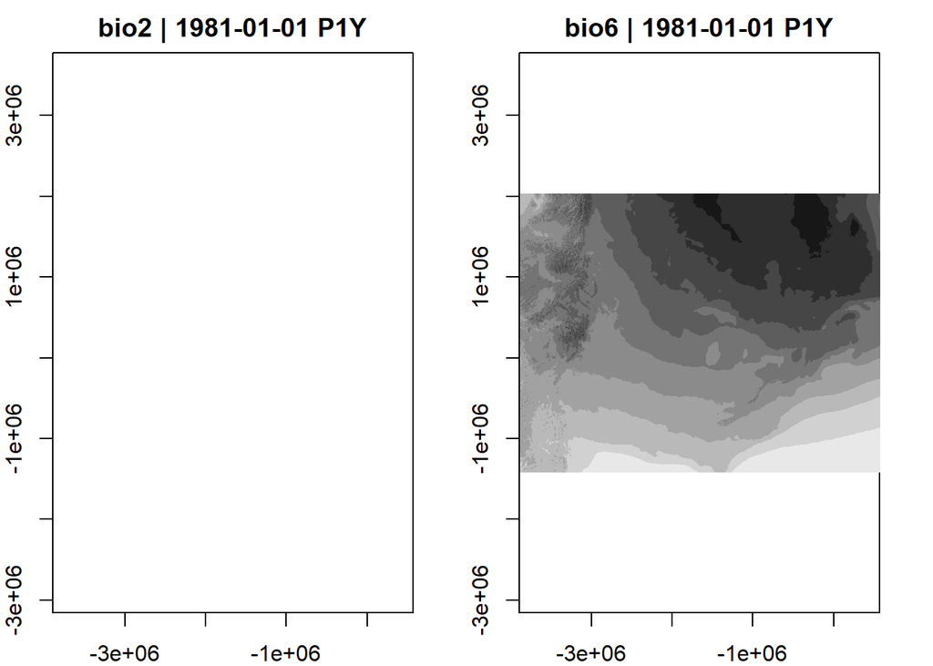

```r
cube %>% plot()
```

The function plot() directly applied to the cube may create akward visualization with apparently empty data, as for bio2. It is caused because the color palette is the same for all the plotted variables.

For better visualization (and for export), the cube can be converted to classic raster format in R. The custom-built cube_to_raster function allows converting either to the raster or terra format, using the argument format.

```r
my.raster <- cube_to_raster(cube, format = "terra")
my.raster
```

```
## class       : SpatRaster
## dimensions  : 1727, 2227, 2  (nrow, ncol, nlyr)
## resolution  : 2000, 2000  (x, y)
## extent      : -3887849, 566150.5, -1416577, 2037423  (xmin, xmax, ymin, ymax)
## coord. ref. : NAD83 / Quebec Albers (EPSG:6623)
## sources     : memory
##               memory
## names       : bio2, bio6
## min values  :   13, 2392
## max values  :  173, 2922
```

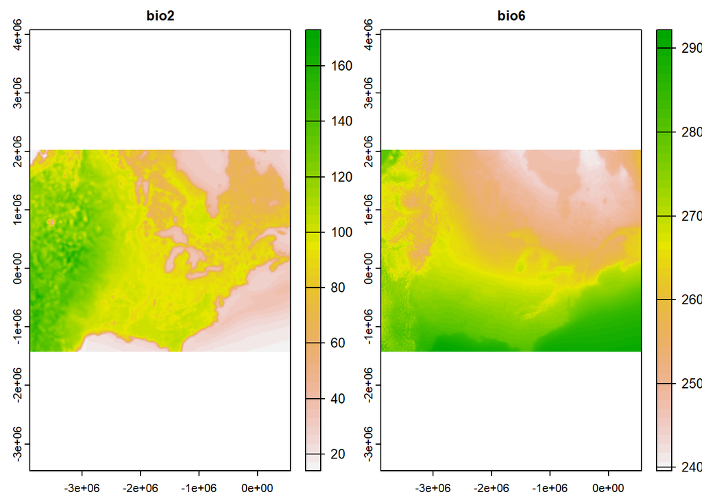

```r
plot(my.raster)
```

It’s better ! The drawback is that the two rasters are now loaded in your current session and uses memory. If you don’t need to load them yet as rasters, we advice to keep them as a cube.

To extract the values of variables for a set of points, we can use the function `extract_geom` from the `gdalcubes` package. Points have to be in a sf format.

```r
value.points <- gdalcubes::extract_geom(cube, sf::st_as_sf(obs_pts))

head(value.points)
```

```
##    FID       time bio2 bio6
## 1 1470 1981-01-01   73 2422
## 2 1471 1981-01-01   73 2422
## 3 1127 1981-01-01   77 2617
## 4 1128 1981-01-01   77 2617
## 5 1130 1981-01-01   75 2618
## 6 1132 1981-01-01   77 2617
```

#### Loading future climate data

```r
cube.future <- load_cube_projection(stac_path =
                                    "https://io.biodiversite-quebec.ca/stac/",
                                  limit = 5000,
                                  collections = c('chelsa-clim-proj'),
                                  bbox = bbox,
                                  rcp = 'ssp126', #ssp126, ssp370, ssp585
                                  srs.cube = srs_cube,
                                  variable = "bio1",
                                  time.span = "2041-2070", #2041-2070 or 2071-2100
                                  spatial.res = 1000,
                                  temporal.res  = "P1Y",
                                  aggregation = "mean",
                                  resampling = "near")
```

Variable extraction also uses the extract_geom function but the output is different. The output table contains one column per variable and per climatic model.

```r
value.points.future <- extract_geom(cube.future, sf::st_as_sf(obs_pts))

head(value.points.future)
```

```
##    FID       time bio1_2041-2070_gfdl-esm4_ssp126
## 1 1127 2041-01-01                            2814
## 2 1128 2041-01-01                            2814
## 3 1130 2041-01-01                            2814
## 4 1132 2041-01-01                            2814
## 5 1133 2041-01-01                            2813
## 6 1134 2041-01-01                            2814
##   bio1_2041-2070_ipsl-cm6a-lr_ssp126 bio1_2041-2070_mpi-esm1-2-hr_ssp126
## 1                               2815                                2808
## 2                               2815                                2808
## 3                               2815                                2808
## 4                               2815                                2808
## 5                               2814                                2807
## 6                               2815                                2808
##   bio1_2041-2070_mri-esm2-0_ssp126 bio1_2041-2070_ukesm1-0-ll_ssp126
## 1                             2817                              2830
## 2                             2817                              2830
## 3                             2817                              2831
## 4                             2817                              2830
## 5                             2816                              2829
## 6                             2817                              2830
```

We extract the name of the variable, the year, the model and the scenario from the column names, then we aggregate the value by point and bioclimatic variable using the mean (we could use another function such as median, min, etc.)

```r
value.points.future <- value.points.future %>% tidyr::pivot_longer(
    cols = dplyr::starts_with("bio"),
    names_to = c("variable", "year", "model", "scenario"),
    names_pattern = "(.*)_(.*)_(.*)_(.*)",
    values_to = "value"
  )  %>%
  dplyr::group_by(FID, variable) %>% dplyr::summarise(mean = mean(value))
```

[output not shown]

```r
head(value.points.future)
```

```
## # A tibble: 6 x 3
## # Groups:   FID [6]
##     FID variable  mean
##   <int> <chr>    <dbl>
## 1     1 bio1     2871.
## 2     2 bio1     2852.
## 3     3 bio1     2875
## 4     4 bio1     2853.
## 5     5 bio1     2870.
## 6     6 bio1     2815.
```

We eventually convert the data into a tidy dataframe.

```r
value.points.future <- value.points.future %>%
     tidyr::pivot_wider(names_from = variable, values_from = mean)
head(value.points.future)
```

```
## # A tibble: 6 x 2
## # Groups:   FID [6]
##     FID  bio1
##   <int> <dbl>
## 1     1 2871.
## 2     2 2852.
## 3     3 2875
## 4     4 2853.
## 5     5 2870.
## 6     6 2815.
```

#### Loading land cover data

We load ESA time series for the year 2000. We decrease the resolution from 250m to 2000m. As land coer is a categorical variable, we select the aggregation method “mode”

```r
cube <-
  load_cube(stac_path = "https://io.biodiversite-quebec.ca/stac/",
           collections = c("esacci-lc"),
           bbox = bbox,
           srs.cube = srs_cube,
           t0 = "2000-01-01",
           t1 = "2000-01-01",
           spatial.res = 2000, # in meters
           temporal.res =  "P1Y",
           aggregation = "mode",
           resampling = "near")
```

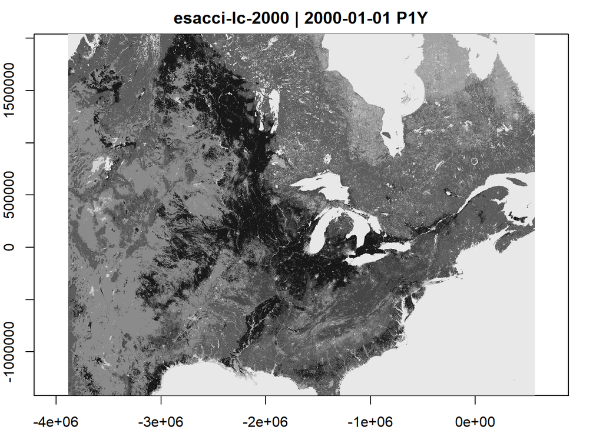

```r
plot(cube)
```

#### Loading soil data

Let’s have a look at the collection:

```r
info_soil <- get_info_collection(stac_path =
                                  "http://io.biodiversite-quebec.ca/stac/",
                                collections = c('soilgrids'),
                                bbox = NULL)

print(info_soil$variables)
```

```
##  [1] "wv1500"   "wv0033"   "wv0010"   "soc"      "silt"     "sand"
##  [7] "phh2o"    "ocs"      "ocd"      "nitrogen" "clay"     "cfvo"
## [13] "cec"      "bdod"
```

```r
print(info_soil$layers)
```

```
##  [1] "wv1500_60-100cm"    "wv1500_5-15cm"      "wv1500_30-60cm"
##  [4] "wv1500_15-30cm"     "wv1500_100-200cm"   "wv1500_0-5cm"
##  [7] "wv0033_60-100cm"    "wv0033_5-15cm"      "wv0033_30-60cm"
## [10] "wv0033_15-30cm"     "wv0033_100-200cm"   "wv0033_0-5cm"
## [13] "wv0010_60-100cm"    "wv0010_5-15cm"      "wv0010_30-60cm"
## [16] "wv0010_15-30cm"     "wv0010_100-200cm"   "wv0010_0-5cm"
## [19] "soc_60-100cm"       "soc_5-15cm"         "soc_30-60cm"
## [22] "soc_15-30cm"        "soc_100-200cm"      "soc_0-5cm"
## [25] "silt_60-100cm"      "silt_5-15cm"        "silt_30-60cm"
## [28] "silt_15-30cm"       "silt_100-200cm"     "silt_0-5cm"
## [31] "sand_60-100cm"      "sand_5-15cm"        "sand_30-60cm"
## [34] "sand_15-30cm"       "sand_100-200cm"     "sand_0-5cm"
## [37] "phh2o_60-100cm"     "phh2o_5-15cm"       "phh2o_30-60cm"
## [40] "phh2o_15-30cm"      "phh2o_100-200cm"    "phh2o_0-5cm"
## [43] "ocs_0-30cm"         "ocd_60-100cm"       "ocd_5-15cm"
## [46] "ocd_30-60cm"        "ocd_15-30cm"        "ocd_100-200cm"
## [49] "ocd_0-5cm"          "nitrogen_60-100cm"  "nitrogen_5-15cm"
## [52] "nitrogen_30-60cm"   "nitrogen_15-30cm"   "nitrogen_100-200cm"
## [55] "nitrogen_0-5cm"     "clay_60-100cm"      "clay_5-15cm"
## [58] "clay_30-60cm"       "clay_15-30cm"       "clay_100-200cm"
## [61] "clay_0-5cm"         "cfvo_60-100cm"      "cfvo_5-15cm"
## [64] "cfvo_30-60cm"       "cfvo_15-30cm"       "cfvo_100-200cm"
## [67] "cfvo_0-5cm"         "cec_60-100cm"       "cec_5-15cm"
## [70] "cec_30-60cm"        "cec_15-30cm"        "cec_100-200cm"
## [73] "cec_0-5cm"          "bdod_60-100cm"      "bdod_5-15cm"
## [76] "bdod_30-60cm"       "bdod_15-30cm"       "bdod_100-200cm"
## [79] "bdod_0-5cm"
```

In this collection, each variable is declined in several depths. Let’s download the proportion of sand, whatever the depth.

```r
cube <-
  load_cube(stac_path = "https://io.biodiversite-quebec.ca/stac/",
           collections = c("soilgrids"),
           bbox = bbox,
           variable = "sand",
           srs.cube = srs_cube,
           limit = 5000,
           spatial.res = 1000, # in meters
           temporal.res =  "P1Y",
           aggregation = "mean",
           resampling = "near")
cube
```

```
## A data cube proxy object
##
## Dimensions:
##                 low             high count pixel_size chunk_size
## t        2016-01-01       2016-12-31     1        P1Y          1
## y -1416577.48418256 2037422.51581744  3454       1000       1024
## x -3887349.45715358  565650.54284642  4453       1000       1024
##
## Bands:
##             name offset scale nodata unit
## 1     sand_0-5cm      0     1    NaN
## 2 sand_100-200cm      0     1    NaN
## 3   sand_15-30cm      0     1    NaN
## 4   sand_30-60cm      0     1    NaN
## 5    sand_5-15cm      0     1    NaN
## 6  sand_60-100cm      0     1    NaN
```

We can also directly select a specific variable and depth by specifying the layer name:

```r
cube <-
  load_cube(stac_path = "https://io.biodiversite-quebec.ca/stac/",
           collections = c("soilgrids"),
           bbox = bbox,
           layers = "sand_100-200cm",
           srs.cube = srs_cube,
           limit = 5000,
           spatial.res = 1000, # in meters
           temporal.res =  "P1Y",
           aggregation = "mean",
           resampling = "near")
cube
```

```
## A data cube proxy object
##
## Dimensions:
##                 low             high count pixel_size chunk_size
## t        2016-01-01       2016-12-31     1        P1Y          1
## y -1416577.48418256 2037422.51581744  3454       1000       1024
## x -3887349.45715358  565650.54284642  4453       1000       1024
##
## Bands:
##             name offset scale nodata unit
## 1 sand_100-200cm      0     1    NaN
```

### To continue: usefull ressources

- gdalcube doc: https://cran.r-project.org/web/packages/gdalcubes/gdalcubes.pdf
- Examples based on gdalcubes library: https://github.com/appelmar/gdalcubes_R